# DL workshop on PyTorch

- 16th Apr - 19th April 8:30 - 10:30 PM
- recording and colab will be provided
- From home OPPE will be there before **next term starts**
- Attendence is not mandatory
- Instructor (Manojkumar Khara)
- [Drive Folder](https://drive.google.com/drive/folders/1KoXiuYgGW2xXoiqR3dB4tOWMTk5bTBQn?usp=sharing)

# Topics

- Tensors, Pytorch popular Functions
- ANN, Pipeline, DataLoader ,
- CNN - image data
- RNN - Text Data

LSTM , GRU , Encoder-Decoder, Transformers

- PyTorch(Meta)—> Numpy, Research Paper, ChatGPT (pytorch), HuggingFace
- Tensorflow(Google) —> Industrial

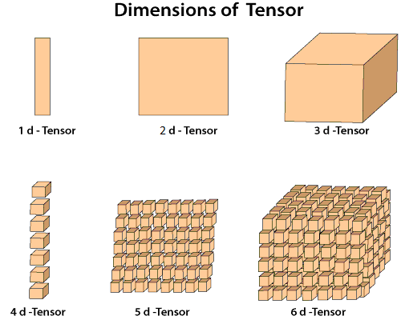

image.png

both NumPy arrays and tensors are multi-dimensional arrays

What Tensor can ? - GPU Acceleration - Automatic Differentiation

Pytorch - Tensor Computations - GPU Acceleration - Dynamic Computation Graph - Automatic Differentiation - Distributed Training

0 dim tensor: Scaler - Loss value

1 dim tensor : vector - Word Embedding

2 dim tensor : Matrix - Gray scale image

[[256, 0, 128],  
[30, 64, 50]]

3 dim tensor : - RGB color image - (width, height, channels)

4 dim tensor : - A batch of RGB color image - (batch, width, height, channels)

5 dim tensor : - video data - Sequence of RGB color image (video) - (batch,frames, width, height, channels)

6 dim tensor : - Multiple video clips - (batch, clip, frames, width, height, channels)

Required tensors in DL: - Training data storage and representation - Parameters (Weights, biases) - Gradients (backpropagation) - Mathematical operations (add , matmul etc.)

References:

- [pin memory](https://developer.nvidia.com/blog/how-optimize-data-transfers-cuda-cc/)
- CUDA® is a parallel computing platform and programming model developed by NVIDIA for general computing on graphical processing units (GPUs). With CUDA, developers are able to dramatically speed up computing applications by harnessing the power of GPUs.

```python
# Check if GPU is available
import torch
# print(torch.cuda.is_available())
# torch.cuda.get_device_name(0)
```

```python
torch.__version__
```

```
'2.6.0+cu124'
```

| Module | Description |
| --- | --- |
| torch | The core module providing multidimensional arrays (tensors) and mathematical operations on them. |
| torch.autograd | Automatic differentiation engine that records operations on tensors to compute gradients for optimization. |
| torch.nn | Provides a neural networks library, including layers, activations, loss functions, and utilities to build deep learning models. |
| torch.optim | Contains optimization algorithms (optimizers) like SGD, Adam, and RMSprop used for training neural networks. |
| torch.utils.data | Utilities for data handling, including the Dataset and DataLoader classes for managing and loading datasets efficiently. |
| torch.distributed | Tools for distributed training across multiple GPUs and machines, facilitating parallel computation. |
| torch.cuda | Interfaces with NVIDIA CUDA to enable GPU acceleration for tensor computations and model training. |
| torch.multiprocessing | Utilities for parallelism using multiprocessing, similar to Python’s multiprocessing module but with support for CUDA tensors. |
| torch.quantization | Tools for model quantization to reduce model size and improve inference speed, especially on edge devices. |
| torch. onnx | Supports exporting PyTorch models to the ONNX (Open Neural Network Exchange) format for interoperability with other frameworks and deployment. |

torchvision  
[torchtext](https://pytorch.org/text/stable/index.html)  
[torchaudio](https://pytorch.org/audio/stable/index.html)

```python
#@title Creating tensor
first_var = torch.tensor(2) # scalar tensor
first_var
```

```
tensor(2)
```

```python
# .ndim
first_var.ndim
```

```
0
```

```python
a = torch.tensor([2,3,4,5])
a
```

```
tensor([2, 3, 4, 5])
```

```python
a.ndim
```

```
1
```

```python
a.shape
```

```
torch.Size([4])
```

```python
b = torch.tensor([[1,2,3],[3,4,5]])
b
```

```
tensor([[1, 2, 3],
        [3, 4, 5]])
```

```python
b.ndim
```

```
2
```

```python
b.shape
```

```
torch.Size([2, 3])
```

```python
b.dtype
```

```
torch.int64
```

```python
#check dtype
int, float, double, short, long

8, 16, 32, 64
```

```python
a = torch.tensor([1.3,2.4,3], dtype = torch.float32)
a
```

```
tensor([1.3000, 2.4000, 3.0000])
```

```python
a.dtype
```

```
torch.float32
```

```python
# prompt: change the dtype of a to int32

b = torch.tensor(a, dtype = torch.int32)
b
```

```
UserWarning: To copy construct from a tensor, it is recommended to use sourceTensor.clone().detach() or sourceTensor.clone().detach().requires_grad_(True), rather than torch.tensor(sourceTensor).
  b = torch.tensor(a, dtype = torch.int32)
```

```
tensor([1, 2, 3], dtype=torch.int32)
```

```python
# empty
c= torch.empty((2,3), dtype=torch.int64)
c
```

```
tensor([[137191861376448,        10759048, 137187316199856],
        [             65,       171150544, 137191881579792]])
```

```python
id(c)
```

```
137187256662352
```

```python
#zeros
torch.zeros(3,4)
```

```
tensor([[0., 0., 0., 0.],
        [0., 0., 0., 0.],
        [0., 0., 0., 0.]])
```

```python
#ones
torch.ones(4,4)
```

```
tensor([[1., 1., 1., 1.],
        [1., 1., 1., 1.],
        [1., 1., 1., 1.],
        [1., 1., 1., 1.]])
```

```python
#manual_seed
#rand
torch.manual_seed(42) # only for this cell
a = torch.rand(3,4) # initialize the weights
b = torch.rand(3,4) # initialize the weights
c = torch.rand(3,4) # initialize the weights

print(a)
print(b)
print(c)
```

```
tensor([[0.8823, 0.9150, 0.3829, 0.9593],
        [0.3904, 0.6009, 0.2566, 0.7936],
        [0.9408, 0.1332, 0.9346, 0.5936]])
tensor([[0.8694, 0.5677, 0.7411, 0.4294],
        [0.8854, 0.5739, 0.2666, 0.6274],
        [0.2696, 0.4414, 0.2969, 0.8317]])
tensor([[0.1053, 0.2695, 0.3588, 0.1994],
        [0.5472, 0.0062, 0.9516, 0.0753],
        [0.8860, 0.5832, 0.3376, 0.8090]])
```

```python
torch.manual_seed(43) # only for this cell
a = torch.rand(3,4) # initialize the weights
print(a)
```

```
tensor([[0.4540, 0.1965, 0.9210, 0.3462],
        [0.1481, 0.0858, 0.5909, 0.0659],
        [0.7476, 0.6253, 0.9392, 0.1338]])
```

```python
# torch.manual_seed(42)
torch.rand(3,4) # initialize the weights
```

[output not shown]

```python
#arange
torch.arange(0,10,2)
```

```
tensor([0, 2, 4, 6, 8])
```

```python
#linspace
torch.linspace(5, 20, 4)
```

```
tensor([ 5., 10., 15., 20.])
```

```python
#eye (identity matrix)
torch.eye(5)
```

```
tensor([[1., 0., 0., 0., 0.],
        [0., 1., 0., 0., 0.],
        [0., 0., 1., 0., 0.],
        [0., 0., 0., 1., 0.],
        [0., 0., 0., 0., 1.]])
```

```python
#diag
torch.diag(torch.tensor([2,5,7,8]))
```

```
tensor([[2, 0, 0, 0],
        [0, 5, 0, 0],
        [0, 0, 7, 0],
        [0, 0, 0, 8]])
```

```python
#full
torch.full((2,3), 3)
```

```
tensor([[3, 3, 3],
        [3, 3, 3]])
```

#dtypes

```python
#int32
```

```python
#int64 or long
```

```python
#float32
```

```python
#float64
```

# Shape

```python
#shape
t1 = torch.tensor([[2,3],[1,4],[5,6], [0,9]])
t1 # 4, 2
```

```
tensor([[2, 3],
        [1, 4],
        [5, 6],
        [0, 9]])
```

```python
#dim
t1.dim()
```

```
2
```

```python
#reshape
t1.reshape(2,2,2) #
```

```
tensor([[[2, 3],
         [1, 4]],

        [[5, 6],
         [0, 9]]])
```

```python
#flatten
t1.flatten() #
```

```
tensor([2, 3, 1, 4, 5, 6, 0, 9])
```

```python
mat = torch.rand(3,2,3,2)
mat
```

```
tensor([[[[0.4290, 0.9433],
          [0.3099, 0.7041],
          [0.5546, 0.9049]],

         [[0.8079, 0.1751],
          [0.4293, 0.4821],
          [0.3575, 0.8633]]],


        [[[0.9868, 0.0859],
          [0.3022, 0.9769],
          [0.5725, 0.3565]],

         [[0.8549, 0.4412],
          [0.3164, 0.0559],
          [0.8365, 0.3794]]],


        [[[0.1790, 0.1516],
          [0.1446, 0.6527],
          [0.6668, 0.5907]],

         [[0.1872, 0.0458],
          [0.2137, 0.1709],
          [0.6042, 0.6840]]]])
```

```python
mat.flatten()
```

```
tensor([0.4290, 0.9433, 0.3099, 0.7041, 0.5546, 0.9049, 0.8079, 0.1751, 0.4293,
        0.4821, 0.3575, 0.8633, 0.9868, 0.0859, 0.3022, 0.9769, 0.5725, 0.3565,
        0.8549, 0.4412, 0.3164, 0.0559, 0.8365, 0.3794, 0.1790, 0.1516, 0.1446,
        0.6527, 0.6668, 0.5907, 0.1872, 0.0458, 0.2137, 0.1709, 0.6042, 0.6840])
```

```python
#permute (2 x 3 x 4) --> (3 X 2 X 4)

#unsqueeze
#squeeze
```

```python
mat = torch.rand(3,2,4) # 3 X 2 X 4
mat
```

```
tensor([[[0.3125, 0.0432, 0.8238, 0.7128],
         [0.3013, 0.3151, 0.4871, 0.2836]],

        [[0.7665, 0.5883, 0.2020, 0.0844],
         [0.3058, 0.1009, 0.4051, 0.3965]],

        [[0.2865, 0.5662, 0.2777, 0.7841],
         [0.7903, 0.3681, 0.2918, 0.0352]]])
```

```python
torch.permute(mat, (2,0,1)) # 4 X 3 X 2
```

```
tensor([[[0.3125, 0.3013],
         [0.7665, 0.3058],
         [0.2865, 0.7903]],

        [[0.0432, 0.3151],
         [0.5883, 0.1009],
         [0.5662, 0.3681]],

        [[0.8238, 0.4871],
         [0.2020, 0.4051],
         [0.2777, 0.2918]],

        [[0.7128, 0.2836],
         [0.0844, 0.3965],
         [0.7841, 0.0352]]])
```

```python
torch.unsqueeze(mat, dim = 2)
```

```
tensor([[[[0.3125, 0.0432, 0.8238, 0.7128]],

         [[0.3013, 0.3151, 0.4871, 0.2836]]],


        [[[0.7665, 0.5883, 0.2020, 0.0844]],

         [[0.3058, 0.1009, 0.4051, 0.3965]]],


        [[[0.2865, 0.5662, 0.2777, 0.7841]],

         [[0.7903, 0.3681, 0.2918, 0.0352]]]])
```

```python
b = torch.rand(1,5,3,1)
b
```

```
tensor([[[[0.6473],
          [0.0379],
          [0.8159]],

         [[0.8852],
          [0.4247],
          [0.0985]],

         [[0.2929],
          [0.6726],
          [0.1386]],

         [[0.3796],
          [0.3385],
          [0.2939]],

         [[0.8167],
          [0.1573],
          [0.6731]]]])
```

```python
c = torch.squeeze(b)
c
```

```
tensor([[0.6473, 0.0379, 0.8159],
        [0.8852, 0.4247, 0.0985],
        [0.2929, 0.6726, 0.1386],
        [0.3796, 0.3385, 0.2939],
        [0.8167, 0.1573, 0.6731]])
```

```python
torch.unsqueeze(c, )
```

[output not shown]

# similiar shape tensors

```python
#empty_like
t1 = torch.rand(2,3)
t1
```

```
tensor([[0.2141, 0.5516, 0.9147],
        [0.0856, 0.1362, 0.8033]])
```

```python
t2 = torch.empty_like(t1)
t2
```

```
tensor([[8.1619e-33, 0.0000e+00, 3.0098e-32],
        [0.0000e+00, 8.9683e-44, 0.0000e+00]])
```

```python
#zeros_like
t2 = torch.zeros_like(t1)
t2
```

```
tensor([[0., 0., 0.],
        [0., 0., 0.]])
```

```python
#ones_like
```

```python
#rand_like
```

# Mathematical Operations

```python
#scalar addition
a= torch.tensor(2)
b = torch.tensor(3)
a+b
```

```
tensor(5)
```

```python
b + 5
```

```
tensor(8)
```

```python
#scalar substraction
b - 1
```

```
tensor(2)
```

```python
#scalar multiplication
b*2
```

```
tensor(6)
```

```python
#scalar division /
b / 2
```

```
tensor(1.5000)
```

```python
#scalar division //
b // 2
```

```
tensor(1)
```

```python
# mod remainder
b % 2
```

```
tensor(1)
```

```python
# power
b ** 2
```

```
tensor(9)
```

#elementwise operations

```python
#add
#multipl
#abs
#neg
#round
#ceil
#floor
#clamp
```

```python
t1 = torch.tensor([[-1,2,3], [4,5,-6]])
t2 = torch.tensor( [[1,1,1], [2,2,2]])
```

```python
torch.add(t1,t2)
```

```
tensor([[ 0,  3,  4],
        [ 6,  7, -4]])
```

```python
t1 + t2
```

```
tensor([[ 0,  3,  4],
        [ 6,  7, -4]])
```

```python
t1 * t2
```

```
tensor([[ -1,   2,   3],
        [  8,  10, -12]])
```

```python
torch.abs(t1)
```

```
tensor([[1, 2, 3],
        [4, 5, 6]])
```

```python
torch.neg(t1)
```

```
tensor([[ 1, -2, -3],
        [-4, -5,  6]])
```

```python
t3= torch.tensor([-5,-2, 0 ,1,2,3,4])
t3
```

```
tensor([-5, -2,  0,  1,  2,  3,  4])
```

```python
torch.clamp(t3, min=0)
```

```
tensor([0, 0, 0, 1, 2, 3, 4])
```

# stats

```python
t1
```

```
tensor([[-1,  2,  3],
        [ 4,  5, -6]])
```

```python
#sum
t1.sum()
```

```
tensor(7)
```

```python
#sum along axis
t1.sum(axis= 0)
```

```
tensor([ 3,  7, -3])
```

```python
#sum along axis
t1.sum(axis= 1)
```

```
tensor([4, 3])
```

```python
#mean
t2 = torch.tensor([[1,2,4], [2,5,6]], dtype= torch.float)
t2.mean()
```

```
tensor(3.3333)
```

```python
t2.mean(axis=1)
```

```
tensor([2.3333, 4.3333])
```

```python
#median
t2.median()
```

```
tensor(2.)
```

```python
#max
t2.max()
```

```
tensor(6.)
```

```python
#min
t2.min()
```

```
tensor(1.)
```

```python
#std
t2.std()
```

```
tensor(1.9664)
```

```python
#argmax, argmin
t2.argmax()
```

```
tensor(5)
```

```python
t2.argmin()
```

```
tensor(0)
```

# matrix operation

```python
 #matmul
 t1 = torch.tensor([[1,2,3], [4,5,6]]) #2X3
 t2 = torch.tensor([[1,2], [3,4], [5,6]]) # 3 x 2
```

```python
torch.matmul(t1,t2)
```

```
tensor([[22, 28],
        [49, 64]])
```

```python
#dot
t1 = torch.tensor([1,2,3])
t2 = torch.tensor([4,5,6])
torch.dot(t1,t2)
```

```
tensor(32)
```

```python
#transpose
t1 = torch.tensor([[1,2,3], [4,5,6]])
torch.transpose(t1,0,1)
```

```
tensor([[1, 4],
        [2, 5],
        [3, 6]])
```

```python
# determinant
# inverse
```

# Comparison

```python
#greater than
t1 = torch.tensor([[1,2], [3,4]])
t2 = torch.tensor([[5,1], [0,7]])
t1 > t2
```

```
tensor([[False,  True],
        [ True, False]])
```

```python
t1 <  t2
```

```
tensor([[ True, False],
        [False,  True]])
```

```python
#less than
```

```python
#equal to

t1 == t2
```

```
tensor([[False, False],
        [False, False]])
```

# important functions

```python
#log
torch.log(t1)
```

```
tensor([[0.0000, 0.6931],
        [1.0986, 1.3863]])
```

```python
#exp
torch.exp(t1)
```

```
tensor([[ 2.7183,  7.3891],
        [20.0855, 54.5981]])
```

```python
#square
torch.square(t1)
```

```
tensor([[ 1,  4],
        [ 9, 16]])
```

```python
#sqrt
torch.sqrt(t1)
```

```
tensor([[1.0000, 1.4142],
        [1.7321, 2.0000]])
```

```python
#sigmoid # 1 / 1 + e^z
torch.sigmoid(t1)
```

```
tensor([[0.7311, 0.8808],
        [0.9526, 0.9820]])
```

```python
def find_sigmoid(t):
  return 1 / (1 + torch.exp(-t))

find_sigmoid(t1)
```

```
tensor([[0.7311, 0.8808],
        [0.9526, 0.9820]])
```

```python
#softmax
t1 = torch.tensor([[1,2], [3,4]], dtype= torch.float32)
torch.softmax(t1, axis= 1)
```

```
tensor([[0.2689, 0.7311],
        [0.2689, 0.7311]])
```

```python
torch.softmax(t1, dim= 1)
```

```
tensor([[0.2689, 0.7311],
        [0.2689, 0.7311]])
```

```python
#relu
t1 = torch.tensor([[-1,2], [3,-4]], dtype= torch.float32)
torch.relu(t1)
```

```
tensor([[0., 2.],
        [3., 0.]])
```

# Inplace operation

```python
a = torch.tensor([1,2,3])
b = torch.tensor([4,5,6])
c = a+b
```

```python
a.add_(b)
```

[output not shown]

```python
w = torch.tensor([4,5,6])
grad = torch.tensor([2,1,3])

w.subtract_(grad)
w
```

```
tensor([2, 4, 3])
```

```python
w.zero_()
```

```
tensor([0, 0, 0])
```

# clone

```python
#clone
a = torch.tensor([1,2,3])
b = a
b
```

```
tensor([1, 2, 3])
```

```python
id(a)
```

```
137187252920080
```

```python
id(b)
```

```
137187252920080
```

```python
b.add_(1)
```

```
tensor([2, 3, 4])
```

```python
a
```

```
tensor([2, 3, 4])
```

```python
c= torch.clone(a)
c
```

```
tensor([2, 3, 4])
```

```python
id(c)
```

```
137187252921424
```

```python
c.add_(1)
```

```
tensor([3, 4, 5])
```

```python
a
```

```
tensor([2, 3, 4])
```